# Replication of Figure 1 in Ligon, Thomas & Worrall (2002)

Mizuhiro Suzuki

5/9/2018

## Replicate Figure 1 of Ligon, Thomas & Worrall (2002)

In this document, my goal is to replicate Figure 1 of Ligon, Thomas & Worrall (2002). For this, I need to derive upper and lower bounds of intervals of the ratio of marginal utilities. I derive them by considering 4 cases separately; autarky case, non-overlapping case, overlapping case, and first best case.

Before diving into the derivations, there are several facts that we know (p.221 in the paper):

1. since all penalties are zero, from Proposition 2(iv), $\lambda_{lh, lower} = \xi_{lh} = 1 / 2$ and $\lambda_{hl, upper} = \xi_{hl} = 2$, and
2. because of the log-form utility functions, the $hh$ and $ll$ $\lambda$-intervals are identical.

Here, I define common parameters and the utility functions:

```r
# y_low and y_high (I decide)
y_l <- 2 / 3
y_h <- 4 / 3
# p = 0.1 (given in the paper)
p <- 0.1
# utility functions are log form (and common for two households)
# Note that this utility functions cannot be changed in this document
# since the log form is used when I derive transfer amounts and
# the log form makes the hh and ll lambda-intervals identical.
u <- function(c){
  object <- log(c)
  return(object)
}
v <- function(c){
  object <- log(c)
  return(object)
}
```

I choose $y_l$ and $y_h$ so that the mean is 1 and $y_l / y_h = 1/2$ as in the original paper. The log utility functions and the equation (11) in the paper tell us the transfer amounts are given as $\lambda$: $\tau_s = \frac{y_1(s) - y_2(s) \lambda}{1 + \lambda}$.

### Case 1: Autarky case

Under autarky, there is no transfer and thus the intervals become degenerate. Therefore, $\lambda_{hh, lower} = \lambda_{hh, upper} = 1$, $\lambda_{hl, lower} = \lambda_{hl, upper} = 2$, and $\lambda_{lh, lower} = \lambda_{lh, upper} = 1 / 2$.

### Case 2: Non-overlapping case

To calculate the end-points of the intervals, evaluate profits at the following end-points:

- $\lambda_{lh, upper}$, at which the discounted surplus of 2 is 0 and the next-period ratio of marginal utilities are $\lambda_{lh, upper}$, $\lambda_{hh, lower}$, $\lambda_{ll, lower}$, $\lambda_{hl, lower}$, with probabilities $p(1-p)$, $(1-p)^2$, $p^2$, and $p(1-p)$, respectively.
- $\lambda_{hh, lower}$, at which the discounted surplus of 1 is 0 and the next-period ratio of marginal utilities are $\lambda_{lh, upper}$, $\lambda_{hh, lower}$, $\lambda_{ll, lower}$, $\lambda_{hl, lower}$, with probabilities $p(1-p)$, $(1-p)^2$, $p^2$, and $p(1-p)$, respectively.
- $\lambda_{hh, upper}$, at which the discounted surplus of 2 is 0 and the next-period ratio of marginal utilities are $\lambda_{lh, upper}$, $\lambda_{hh, upper}$, $\lambda_{ll, upper}$, $\lambda_{hl, lower}$, with probabilities $p(1-p)$, $(1-p)^2$, $p^2$, and $p(1-p)$, respectively.
- $\lambda_{hl, lower}$, at which the discounted surplus of 1 is 0 and the next-period ratio of marginal utilities are $\lambda_{lh, upper}$, $\lambda_{hh, upper}$, $\lambda_{ll, upper}$, $\lambda_{hl, lower}$, with probabilities $p(1-p)$, $(1-p)^2$, $p^2$, and $p(1-p)$, respectively.

$\begin{aligned} 0 & = v(y_2(h) + (y_1(l) - y_2(h) \lambda_{lh, upper}) / (1 + \lambda_{lh, upper})) - v(y_2(h)) + \\ & \delta ((1 - 2p + 2p^2) V_{hh, upper} + p (1 - p) V_{hl, upper}) \\ U_{lh, upper} & = u(y_1(l) - (y_1(l) - y_2(h) \lambda_{lh, upper}) / (1 + \lambda_{lh, upper})) - u(y_1(l)) + \\ & \delta p (1 - p) U_{lh, upper} \\ V_{hh, upper} & = v(y_2(h) + (y_1(h) - y_2(h) \lambda_{hh, lower}) / (1 + \lambda_{hh, lower})) - v(y_2(h)) + \\ & \delta ((1 - 2p + 2p^2) V_{hh, upper} + p (1 - p) V_{hl, upper}) \\ 0 & = u(y_1(h) - (y_1(h) - y_2(h) \lambda_{hh, lower}) / (1 + \lambda_{hh, lower})) - u(y_1(h)) + \\ & \delta p (1 - p) U_{lh, upper} \\ 0 & = v(y_2(h) + (y_1(h) - y_2(h) \lambda_{hh, upper}) / (1 + \lambda_{hh, upper})) - v(y_2(h)) + \\ & \delta p (1 - p) V_{hl, upper} \\ U_{hh, upper} & = u(y_1(h) - (y_1(h) - y_2(h) \lambda_{hh, upper}) / (1 + \lambda_{hh, upper})) - u(y_1(h)) + \\ & \delta (p (1 - p) U_{lh, upper} + (1 - 2p + 2p^2) U_{hh, upper}) \\ V_{hl, upper} & = v(y_2(l) + (y_1(h) - y_2(l) \lambda_{hl, lower}) / (1 + \lambda_{hl, lower})) - v(y_2(l)) + \\ & \delta p (1 - p) V_{hl, upper} \\ 0 & = u(y_1(h) - (y_1(h) - y_2(l) \lambda_{hl, lower}) / (1 + \lambda_{hl, lower})) - u(y_1(h)) + \\ & \delta (p (1 - p) U_{lh, upper} + (1 - 2p + 2p^2) U_{hh, upper}) \end{aligned}$

The following function solves this system of equations:

```r
# For the case where there is no overlap, solve end-points and surpluses at these points

no_overlap <- function(x, delta, y_l, y_h, p){
  # x <- c(lambda_{lh, upper}, lambda_{hh, lower}, lambda_{hh, upper}, lambda_{hl, lower},
  #       U_{lh, upper}, V_{hh, upper}, U_{hh, upper}, V_{hl, upper})
  y <- numeric(8)
  y[1] <- v(y_h + (y_l - y_h * x[1]) / (1 + x[1])) - v(y_h) +
            delta * ((1 - 2 * p + 2 * p^2) * x[6] + p * (1 - p) * x[8])
  y[2] <- u(y_l - (y_l - y_h * x[1]) / (1 + x[1])) - u(y_l) +
            delta * (p * (1 - p) * x[5]) - x[5]
  y[3] <- v(y_h + (y_h - y_h * x[2]) / (1 + x[2])) - v(y_h) +
            delta * ((1 - 2 * p + 2 * p^2) * x[6] + p * (1 - p) * x[8]) - x[6]
  y[4] <- u(y_h - (y_h - y_h * x[2]) / (1 + x[2])) - u(y_h) +
            delta * (p * (1 - p) * x[5])
  y[5] <- v(y_h + (y_h - y_h * x[3]) / (1 + x[3])) - v(y_h) +
            delta * (p * (1 - p) * x[8])
  y[6] <- u(y_h - (y_h - y_h * x[3]) / (1 + x[3])) - u(y_h) +
            delta * (p * (1 - p) * x[5] + (1 - 2 * p + 2 * p^2) * x[7]) - x[7]
  y[7] <- v(y_l + (y_h - y_l * x[4]) / (1 + x[4])) - v(y_l) +
            delta * (p * (1 - p) * x[8]) - x[8]
  y[8] <- u(y_h - (y_h - y_l * x[4]) / (1 + x[4])) - u(y_h) +
            delta * (p * (1 - p) * x[5] + (1 - 2 * p + 2 * p^2) * x[7])
  return(y)
}
```

Given this function to solve each end-point, I obtain these end-points in this region, and the threshold with other regions ($\delta_1$ (cutoff between autarky region and no-overlapping region) and $\delta_2$ (cutoff between non-overlapping region and overlapping region)).

```r
delta_vals <- seq(0.80, 0.999, by = 0.0001)
lambda_lh_upper_vals_no_overlap <- numeric(length(delta_vals))
lambda_hh_lower_vals_no_overlap <- numeric(length(delta_vals))
lambda_hh_upper_vals_no_overlap <- numeric(length(delta_vals))
lambda_hl_lower_vals_no_overlap <- numeric(length(delta_vals))
same_as_autarky <- numeric(length(delta_vals))
x_start <- rep((y_l + y_h) / 2, 8)
for (delta in 1:length(delta_vals)){
  no_overlap_solutions <- nleqslv(x_start,
                                  no_overlap,
                                  delta = delta_vals[delta],
                                  y_l = y_l,
                                  y_h = y_h,
                                  p = p)$x
  lambda_lh_upper_vals_no_overlap[delta] <- no_overlap_solutions[1]
  lambda_hh_lower_vals_no_overlap[delta] <- no_overlap_solutions[2]
  lambda_hh_upper_vals_no_overlap[delta] <- no_overlap_solutions[3]
  lambda_hl_lower_vals_no_overlap[delta] <- no_overlap_solutions[4]
  same_as_autarky[delta] <- is.logical(all.equal(no_overlap_solutions[1], y_l / y_h, tolerance = 1e-3))
}

delta_1 <- delta_vals[max(which(same_as_autarky == 1))]
delta_2 <- delta_vals[min(which(lambda_lh_upper_vals_no_overlap
                                >= lambda_hh_lower_vals_no_overlap))]
```

### Case 3: Overlapping case

To calculate the end-points of the intervals, evaluate profits at the following end-points:

- $\lambda_{lh, upper}$, at which the discounted surplus of 2 is 0 and the next-period ratio of marginal utilities are $\lambda_{lh, upper}$ and $\lambda_{hl, lower}$, with probabilities $1 - p(1-p)$ and $p(1-p)$, respectively.
- $\lambda_{hh, lower}$, at which the discounted surplus of 1 is 0 and the next-period ratio of marginal utilities are $\lambda_{hh, lower}$, $\lambda_{ll, lower}$, and $\lambda_{hl, lower}$ with probabilities $(1-p)$, $p^2$, and $p(1-p)$, respectively.
- $\lambda_{hh, upper}$, at which the discounted surplus of 2 is 0 and the next-period ratio of marginal utilities are $\lambda_{lh, upper}$, $\lambda_{hh, upper}$, and $\lambda_{ll, upper}$ with probabilities $p(1-p)$, $(1-p)$, and $p^2$, respectively.
- $\lambda_{hl, lower}$, at which the discounted surplus of 1 is 0 and the next-period ratio of marginal utilities are $\lambda_{lh, upper}$ and $\lambda_{hl, lower}$, with probabilities $p(1-p)$ and $1 - p(1-p)$, respectively.

This is very similar to the previous case, but this case is indeed more complicated. Why?

This is because, in the previous case I only had to consider discounted surpluses at the end-points, in this overlapping case that does not work. For instance, from $\lambda_{lh, upper}$, if {High, High} state realized, then the ratio of marginal utilities remains $\lambda_{lh, upper}$ and it is interior of the intervals $[\lambda_{hh, lower},\lambda_{hh, upper}]$. Therefore, we need to consider the discounted surpluses at that point too!

Here, I define the discounted surpluses at the interior of intervals as the followings:

- $U_{hh}^*, V_{hh}^*$: discounted surpluses when income realization is {High, High} and the ratio of marginal utilities is $\lambda_{lh, upper}$,
- $U_{lh}^*, V_{lh}^*$: discounted surpluses when income realization is {Low, High} and the ratio of marginal utilities is $\lambda_{hh, lower}$,
- $U_{hl}^*, V_{hl}^*$: discounted surpluses when income realization is {High, Low} and the ratio of marginal utilities is $\lambda_{hh, upper}$, and
- $U_{hh}^{**}, V_{hh}^{**}$: discounted surpluses when income realization is {High, High} and the ratio of marginal utilities is $\lambda_{hl, lower}$.

Then, I can write down the conditions:

$\begin{aligned} 0 & = v(y_2(h) + (y_1(l) - y_2(h) \lambda_{lh, upper}) / (1 + \lambda_{lh, upper})) - v(y_2(h)) + \\ & \delta ((1 - 2p + 2p^2) V_{hh}^* + p (1 - p) V_{hl, upper}) \\ U_{lh, upper} & = u(y_1(l) - (y_1(l) - y_2(h) \lambda_{lh, upper}) / (1 + \lambda_{lh, upper})) - u(y_1(l)) + \\ & \delta ((1 - 2p + 2p^2) U_{hh}^* + p (1 - p) U_{lh, upper}) \\ V_{hh}^* & = v(y_2(h) + (y_1(h) - y_2(h) \lambda_{lh, upper}) / (1 + \lambda_{lh, upper})) - v(y_2(h)) + \\ & \delta (p (1 - p) V_{hl, upper} + (1 - 2p + 2p^2) V_{hh}^*) \\ U_{hh}^* & = u(y_1(h) - (y_1(h) - y_2(h) \lambda_{lh, upper}) / (1 + \lambda_{lh, upper})) - u(y_1(h)) + \\ & \delta (p (1 - p) U_{lh, upper} + (1 - 2p + 2p^2) U_{hh}^*) \\ \\ V_{hh, upper} & = v(y_2(h) + (y_1(h) - y_2(h) \lambda_{hh, lower}) / (1 + \lambda_{hh, lower})) - v(y_2(h)) + \\ & \delta ((1 - 2p + 2p^2) V_{hh, upper} + p (1 - p) V_{lh}^* + p (1 - p) V_{hl, upper}) \\ 0 & = u(y_1(h) - (y_1(h) - y_2(h) \lambda_{hh, lower}) / (1 + \lambda_{hh, lower})) - u(y_1(h)) + \\ & \delta p (1 - p) U_{lh}^* \\ V_{lh}^* & = v(y_2(h) + (y_1(l) - y_2(h) \lambda_{hh, lower}) / (1 + \lambda_{hh, lower})) - v(y_2(h)) + \\ & \delta ((1 - 2p + 2p^2) V_{hh, upper} + p (1 - p) V_{lh}^* + p (1 - p) V_{hl, upper}) \\ U_{lh}^* & = u(y_1(l) - (y_1(l) - y_2(h) \lambda_{hh, lower}) / (1 + \lambda_{hh, lower})) - u(y_1(l)) + \\ & \delta p (1 - p) U_{lh}^* \\ \\ 0 & = v(y_2(h) + (y_1(h) - y_2(h) \lambda_{hh, upper}) / (1 + \lambda_{hh, upper})) - v(y_2(h)) + \\ & \delta p (1 - p) V_{hl}^* \\ U_{hh, upper} & = u(y_1(h) - (y_1(h) - y_2(h) \lambda_{hh, upper}) / (1 + \lambda_{hh, upper})) - u(y_1(h)) + \\ & \delta ((1 - 2p + 2p^2) U_{hh, upper} + p (1 - p) U_{hl}^* + p (1 - p) U_{lh, upper}) \\ V_{hl}^* & = v(y_2(l) + (y_1(h) - y_2(l) \lambda_{hh, upper}) / (1 + \lambda_{hh, upper})) - v(y_2(l)) + \\ & \delta p (1 - p) V_{hl}^* \\ U_{hl}^* & = u(y_1(h) - (y_1(h) - y_2(l) \lambda_{hh, upper}) / (1 + \lambda_{hh, upper})) - u(y_1(h)) + \\ & \delta ((1 - 2p + 2p^2) U_{hh, upper} + p (1 - p) U_{hl}^* + p (1 - p) U_{lh, upper}) \\ \\ V_{hl, upper} & = v(y_2(l) + (y_1(h) - y_2(l) \lambda_{hl, lower}) / (1 + \lambda_{hl, lower})) - v(y_2(l)) + \\ & \delta ((1 - 2p + 2p^2) V_{hh}^{**} + p (1 - p) V_{hl, upper}) \\ 0 & = u(y_1(h) - (y_1(h) - y_2(l) \lambda_{hl, lower}) / (1 + \lambda_{hl, lower})) - u(y_1(h)) + \\ & \delta ((1 - 2p + 2p^2) U_{hh}^{**} + p (1 - p) U_{lh, upper}) \\ V_{hh}^{**} & = v(y_2(h) + (y_1(h) - y_2(h) \lambda_{hl, lower}) / (1 + \lambda_{hl, lower})) - v(y_2(h)) + \\ & \delta (p (1 - p) V_{hl, upper} + (1 - 2p + 2p^2) V_{hh}^{**}) \\ U_{hh}^{**} & = u(y_1(h) - (y_1(h) - y_2(h) \lambda_{hl, lower}) / (1 + \lambda_{hl, lower})) - u(y_1(h)) + \\ & \delta (p (1 - p) U_{lh, upper} + (1 - 2p + 2p^2) U_{hh}^{**}) \\ \end{aligned}$

For the discounted surpluses at the interior of intervals, these relationships can be obtained:

$\begin{aligned} V_{hh}^* & = \frac{v(y_2(h) + (y_1(h) - y_2(h) \lambda_{lh, upper}) / (1 + \lambda_{lh, upper})) - v(y_2(h)) + \delta p (1 - p) V_{hl, upper}}{1 - \delta (1 - 2p + 2p^2)} \\ U_{hh}^* & = \frac{u(y_1(h) - (y_1(h) - y_2(h) \lambda_{lh, upper}) / (1 + \lambda_{lh, upper})) - u(y_1(h)) + \delta p (1 - p) U_{lh, upper}}{1 - \delta (1 - 2p + 2p^2)} \\ V_{lh}^* & = \frac{v(y_2(h) + (y_1(l) - y_2(h) \lambda_{hh, lower}) / (1 + \lambda_{hh, lower})) - v(y_2(h)) + \delta ((1 - 2p + 2p^2) V_{hh, upper} + p (1 - p) V_{hl, upper})}{1 - \delta p (1 - p)} \\ U_{lh}^* & = \frac{u(y_1(l) - (y_1(l) - y_2(h) \lambda_{hh, lower}) / (1 + \lambda_{hh, lower})) - u(y_1(l))}{1 - \delta p (1 - p)} \\ V_{hl}^* & = \frac{v(y_2(l) + (y_1(h) - y_2(l) \lambda_{hh, upper}) / (1 + \lambda_{hh, upper})) - v(y_2(l))}{1 - \delta p ( 1 - p)} \\ U_{hl}^* & = \frac{u(y_1(h) - (y_1(h) - y_2(l) \lambda_{hh, upper}) / (1 + \lambda_{hh, upper})) - u(y_1(h)) + \delta ((1 - 2p + 2p^2) U_{hh, upper} + p (1 - p) U_{lh, upper})}{1 - \delta p (1 - p)} \\ V_{hh}^{**} & = \frac{v(y_2(h) + (y_1(h) - y_2(h) \lambda_{hl, lower}) / (1 + \lambda_{hl, lower})) - v(y_2(h)) + \delta p (1 - p) V_{hl, upper}}{1 - \delta (1 - 2p + 2p^2)} \\ U_{hh}^{**} & = \frac{u(y_1(h) - (y_1(h) - y_2(h) \lambda_{hl, lower}) / (1 + \lambda_{hl, lower})) - u(y_1(h)) + \delta p (1 - p) U_{lh, upper}}{1 - \delta (1 - 2p + 2p^2)} \\ \end{aligned}$

Oh man this is A LOT!!! Finally I can define the function to solve this system of equations:

```r
# For the case where there are overlaps, solve end-points and surpluses at these points

overlap <- function(x, delta, y_l, y_h, p){
  # x <- c(lambda_{lh, upper}, lambda_{hh, lower}, lambda_{hh, upper}, lambda_{hl, lower},
  #         U_{lh, upper}, V_{hh, upper}, U_{hh, upper}, V_{hl, upper})
  # First I derive the discounted surpluses at the interior of intervals
  V_hh_star  <- (v(y_h + (y_h - y_h * x[1]) / (1 + x[1])) - v(y_h) +
                 delta * (p - p^2) * x[8]) / (1 - delta * (1 - 2 * p + 2 * p^2))
  U_hh_star  <- (u(y_h - (y_h - y_h * x[1]) / (1 + x[1])) - u(y_h) +
                 delta * (p - p^2) * x[5]) / (1 - delta * (1 - 2 * p + 2 * p^2))

  V_lh_star  <- (v(y_h + (y_l - y_h * x[2]) / (1 + x[2])) - v(y_h) +
                 delta * ((1 - 2 * p + 2 * p^2) * x[6] + (p - p^2) * x[8])) / (1 - delta * (p - p^2))
  U_lh_star  <- (u(y_l - (y_l - y_h * x[2]) / (1 + x[2])) - u(y_l)) / (1 - delta * (p - p^2))

  V_hl_star  <- (v(y_l + (y_h - y_l * x[3]) / (1 + x[3])) - v(y_l)) / (1 - delta * (p - p^2))
  U_hl_star  <- (u(y_h - (y_h - y_l * x[3]) / (1 + x[3])) - u(y_h) +
                 delta * ((1 - 2 * p + 2 * p^2) * x[7] + (p - p^2) * x[5])) / (1 - delta * (p - p^2))

  V_hh_2star <- (v(y_h + (y_h - y_h * x[4]) / (1 + x[4])) - v(y_h) +
                 delta * (p - p^2) * x[8]) / (1 - delta * (1 - 2 * p + 2 * p^2))
  U_hh_2star <- (u(y_h - (y_h - y_h * x[4]) / (1 + x[4])) - u(y_h) +
                 delta * (p - p^2) * x[5]) / (1 - delta * (1 - 2 * p + 2 * p^2))


  y <- numeric(8)
  y[1] <- v(y_h + (y_l - y_h * x[1]) / (1 + x[1])) - v(y_h) +
            delta * ((1 - 2 * p + 2 * p^2) * V_hh_star + (p - p^2) * x[8])
  y[2] <- u(y_l - (y_l - y_h * x[1]) / (1 + x[1])) - u(y_l) +
            delta * ((1 - 2 * p + 2 * p^2) * U_hh_star + (p - p^2) * x[5]) - x[5]

  y[3] <- v(y_h + (y_h - y_h * x[2]) / (1 + x[2])) - v(y_h) +
            delta * ((1 - p + p^2) * x[6] + (p - p^2) * V_lh_star + (p - p^2) * x[8])     - x[6]
  y[4] <- u(y_h - (y_h - y_h * x[2]) / (1 + x[2])) - u(y_h) +
            delta * (p - p^2) * U_lh_star

  y[5] <- v(y_h + (y_h - y_h * x[3]) / (1 + x[3])) - v(y_h) +
            delta * (p - p^2) * V_hl_star
  y[6] <- u(y_h - (y_h - y_h * x[3]) / (1 + x[3])) - u(y_h) +
            delta * ((1 - p + p^2) * x[7] + (p - p^2) * U_hl_star + (p - p^2) * x[5])     - x[7]

  y[7] <- v(y_l + (y_h - y_l * x[4]) / (1 + x[4])) - v(y_l) +
            delta * ((1 - 2 * p + 2 * p^2) * V_hh_2star + (p - p^2) * x[8]) - x[8]
  y[8] <- u(y_h - (y_h - y_l * x[4]) / (1 + x[4])) - u(y_h) +
            delta * ((1 - 2 * p + 2 * p^2) * U_hh_2star + (p - p^2) * x[5])
  return(y)
}
```

Given this function to solve each end-point, I obtain these end-points in this region, and the cutoff between overlapping region and first-best region ($\delta_3$).

```r
delta_vals <- seq(0.80, 0.999, by = 0.0001)
lambda_lh_upper_vals_overlap <- numeric(length(delta_vals))
lambda_hh_lower_vals_overlap <- numeric(length(delta_vals))
lambda_hh_upper_vals_overlap <- numeric(length(delta_vals))
lambda_hl_lower_vals_overlap <- numeric(length(delta_vals))
same_as_autarky <- numeric(length(delta_vals))
x_start <- rep((y_l + y_h) / 2, 8)
for (delta in 1:length(delta_vals)){
  overlap_solutions <- nleqslv(x_start,
                               overlap,
                               delta = delta_vals[delta],
                               y_l = y_l,
                               y_h = y_h,
                               p = p)$x
  lambda_lh_upper_vals_overlap[delta] <- overlap_solutions[1]
  lambda_hh_lower_vals_overlap[delta] <- overlap_solutions[2]
  lambda_hh_upper_vals_overlap[delta] <- overlap_solutions[3]
  lambda_hl_lower_vals_overlap[delta] <- overlap_solutions[4]
}

delta_3 <- delta_vals[min(which(lambda_lh_upper_vals_overlap
                        >= lambda_hl_lower_vals_overlap))]
```

### Case 4: First-best case

To calculate the end-points of the intervals, evaluate profits at the following end-points:

- $\lambda_{lh, upper}$, at which the discounted surplus of 2 is 0 and the next-period ratio of marginal utilities are $\lambda_{lh, upper}$ with probabilities $1$.
- $\lambda_{hh, lower}$, at which the discounted surplus of 1 is 0 and the next-period ratio of marginal utilities are $\lambda_{hh, lower}$, $\lambda_{ll, lower}$, and $\lambda_{hl, lower}$ with probabilities $(1-p)$, $p^2$, and $p(1-p)$, respectively.
- $\lambda_{hh, upper}$, at which the discounted surplus of 2 is 0 and the next-period ratio of marginal utilities are $\lambda_{lh, upper}$, $\lambda_{hh, upper}$, and $\lambda_{ll, upper}$ with probabilities $p(1-p)$, $(1-p)$, and $p^2$, respectively.
- $\lambda_{hl, lower}$, at which the discounted surplus of 1 is 0 and the next-period ratio of marginal utilities are $\lambda_{hl, lower}$ with probabilities $1$.

Here, I define the discounted surpluses at the interior of intervals as the followings:

Then, I can write down the conditions:

$\begin{aligned} 0 & = v(y_2(h) + (y_1(l) - y_2(h) \lambda_{lh, upper}) / (1 + \lambda_{lh, upper})) - v(y_2(h)) + \\ & \delta ((1 - 2p + 2p^2) V_{hh}^{*} + p (1 - p) V_{hl}^{*}) \\ U_{lh, upper} & = u(y_1(l) - (y_1(l) - y_2(h) \lambda_{lh, upper}) / (1 + \lambda_{lh, upper})) - u(y_1(l)) + \\ & \delta ((1 - 2p + 2p^2) U_{hh}^{*} + p (1 - p) U_{hl}^{*} + p (1 - p) U_{lh, upper}) \\ V_{hh}^* & = v(y_2(h) + (y_1(h) - y_2(h) \lambda_{lh, upper}) / (1 + \lambda_{lh, upper})) - v(y_2(h)) + \\ & \delta ((1 - 2p + 2p^2) V_{hh}^{*} + p (1 - p) V_{hl}^{*}) \\ U_{hh}^* & = u(y_1(h) - (y_1(h) - y_2(h) \lambda_{lh, upper}) / (1 + \lambda_{lh, upper})) - u(y_1(h)) + \\ & \delta ((1 - 2p + 2p^2) U_{hh}^{*} + p (1 - p) U_{hl}^{*} + p (1 - p) U_{lh, upper}) \\ V_{hl}^* & = v(y_2(l) + (y_1(h) - y_2(l) \lambda_{lh, upper}) / (1 + \lambda_{lh, upper})) - v(y_2(l)) + \\ & \delta ((1 - 2p + 2p^2) V_{hh}^{*} + p (1 - p) V_{hl}^{*}) \\ U_{hl}^* & = u(y_1(h) - (y_1(h) - y_2(l) \lambda_{lh, upper}) / (1 + \lambda_{lh, upper})) - u(y_1(h)) + \\ & \delta ((1 - 2p + 2p^2) U_{hh}^{*} + p (1 - p) U_{hl}^{*} + p (1 - p) U_{lh, upper}) \\ \\ V_{hh, upper} & = v(y_2(h) + (y_1(h) - y_2(h) \lambda_{hh, lower}) / (1 + \lambda_{hh, lower})) - v(y_2(h)) + \\ & \delta ((1 - 2p + 2p^2) V_{hh, upper} + p (1 - p) V_{lh}^{**} + p (1 - p) V_{hl, upper}) \\ 0 & = u(y_1(h) - (y_1(h) - y_2(h) \lambda_{hh, lower}) / (1 + \lambda_{hh, lower})) - u(y_1(h)) + \\ & \delta p (1 - p) U_{lh}^{**} \\ V_{lh}^{**} & = v(y_2(h) + (y_1(l) - y_2(h) \lambda_{hh, lower}) / (1 + \lambda_{hh, lower})) - v(y_2(h)) + \\ & \delta ((1 - 2p + 2p^2) V_{hh, upper} + p (1 - p) V_{lh}^{**} + p (1 - p) V_{hl, upper}) \\ U_{lh}^{**} & = u(y_1(l) - (y_1(l) - y_2(h) \lambda_{hh, lower}) / (1 + \lambda_{hh, lower})) - u(y_1(l)) + \\ & \delta p (1 - p) U_{lh}^{**} \\ \\ 0 & = v(y_2(h) + (y_1(h) - y_2(h) \lambda_{hh, upper}) / (1 + \lambda_{hh, upper})) - v(y_2(h)) + \\ & \delta p (1 - p) V_{hl}^{***} \\ U_{hh, upper} & = u(y_1(h) - (y_1(h) - y_2(h) \lambda_{hh, upper}) / (1 + \lambda_{hh, upper})) - u(y_1(h)) + \\ & \delta ((1 - 2p + 2p^2) U_{hh, upper} + p (1 - p) U_{hl}^{***} + p (1 - p) U_{lh, upper}) \\ V_{hl}^{***} & = v(y_2(l) + (y_1(h) - y_2(l) \lambda_{hh, upper}) / (1 + \lambda_{hh, upper})) - v(y_2(l)) + \\ & \delta p (1 - p) V_{hl}^* \\ U_{hl}^{***} & = u(y_1(h) - (y_1(h) - y_2(l) \lambda_{hh, upper}) / (1 + \lambda_{hh, upper})) - u(y_1(h)) + \\ & \delta ((1 - 2p + 2p^2) U_{hh, upper} + p (1 - p) U_{hl}^* + p (1 - p) U_{lh, upper}) \\ \\ V_{hl, upper} & = v(y_2(l) + (y_1(h) - y_2(l) \lambda_{hl, lower}) / (1 + \lambda_{hl, lower})) - v(y_2(l)) + \\ & \delta ((1 - 2p + 2p^2) V_{hh}^{****} + p (1 - p) V_{lh}^{****} + p (1 - p) V_{hl, upper}) \\ 0 & = u(y_1(h) - (y_1(h) - y_2(l) \lambda_{hl, lower}) / (1 + \lambda_{hl, lower})) - u(y_1(h)) + \\ & \delta ((1 - 2p + 2p^2) U_{hh}^{****} + p (1 - p) U_{lh}^{****}) \\ V_{hh}^{****} & = v(y_2(h) + (y_1(h) - y_2(h) \lambda_{hl, lower}) / (1 + \lambda_{hl, lower})) - v(y_2(h)) + \\ & \delta ((1 - 2p + 2p^2) V_{hh}^{****} + p (1 - p) V_{lh}^{****} + p (1 - p) V_{hl, upper}) \\ U_{hh}^{****} & = u(y_1(h) - (y_1(h) - y_2(h) \lambda_{hl, lower}) / (1 + \lambda_{hl, lower})) - u(y_1(h)) + \\ & \delta ((1 - 2p + 2p^2) U_{hh}^{****} + p (1 - p) U_{lh}^{****}) \\ V_{lh}^{****} & = v(y_2(h) + (y_1(l) - y_2(h) \lambda_{hl, lower}) / (1 + \lambda_{hl, lower})) - v(y_2(h)) + \\ & \delta ((1 - 2p + 2p^2) V_{hh}^{****} + p (1 - p) V_{lh}^{****} + p (1 - p) V_{hl, upper}) \\ U_{lh}^{****} & = u(y_1(l) - (y_1(l) - y_2(h) \lambda_{hl, lower}) / (1 + \lambda_{hl, lower})) - u(y_1(l)) + \\ & \delta ((1 - 2p + 2p^2) U_{hh}^{****} + p (1 - p) U_{lh}^{****}) \end{aligned}$

For the discounted surpluses at the interior of intervals, these relationships can be obtained (notice that some of the future expected surpluses take the same form due to unchanged $\lambda$’s):

$\begin{aligned} V_{hh}^* &= v(y_2(h) + (y_1(h) - y_2(h) \lambda_{lh, upper}) / (1 + \lambda_{lh, upper})) - v(y_2(h)) - \\ &(v(y_2(h) + (y_1(l) - y_2(h) \lambda_{lh, upper}) / (1 + \lambda_{lh, upper})) - v(y_2(h))) \\ U_{hh}^* &= u(y_1(h) - (y_1(h) - y_2(h) \lambda_{lh, upper}) / (1 + \lambda_{lh, upper})) - u(y_1(h)) + \\ &(U_{lh, upper} - (u(y_1(l) - (y_1(l) - y_2(h) \lambda_{lh, upper}) / (1 + \lambda_{lh, upper})) - u(y_1(l)))) \\ V_{hl}^* &= v(y_2(l) + (y_1(h) - y_2(l) \lambda_{lh, upper}) / (1 + \lambda_{lh, upper})) - v(y_2(l)) - \\ &(v(y_2(h) + (y_1(l) - y_2(h) \lambda_{lh, upper}) / (1 + \lambda_{lh, upper})) - v(y_2(h))) \\ U_{hl}^* &= u(y_1(h) - (y_1(h) - y_2(l) \lambda_{lh, upper}) / (1 + \lambda_{lh, upper})) - u(y_1(h)) + \\ &(U_{lh, upper} - (u(y_1(l) - (y_1(l) - y_2(h) \lambda_{lh, upper}) / (1 + \lambda_{lh, upper})) - u(y_1(l)))) \\ \\ V_{lh}^{**} &= v(y_2(h) + (y_1(l) - y_2(h) \lambda_{hh, lower}) / (1 + \lambda_{hh, lower})) - v(y_2(h)) + \\ &(V_{hh, upper} - (v(y_2(h) + (y_1(h) - y_2(h) \lambda_{hh, lower}) / (1 + \lambda_{hh, lower})) - v(y_2(h)))) \\ U_{lh}^{**} &= u(y_1(l) - (y_1(l) - y_2(h) \lambda_{hh, lower}) / (1 + \lambda_{hh, lower})) - u(y_1(l)) - \\ &(u(y_1(h) - (y_1(h) - y_2(h) \lambda_{hh, lower}) / (1 + \lambda_{hh, lower})) - u(y_1(h))) \\ \\ V_{hl}^{***} &= v(y_2(l) + (y_1(h) - y_2(l) \lambda_{hh, upper}) / (1 + \lambda_{hh, upper})) - v(y_2(l)) - \\ &(v(y_2(h) + (y_1(h) - y_2(h) \lambda_{hh, upper}) / (1 + \lambda_{hh, upper})) - v(y_2(h))) \\ U_{hl}^{***} &= u(y_1(h) - (y_1(h) - y_2(l) \lambda_{hh, upper}) / (1 + \lambda_{hh, upper})) - u(y_1(h)) + \\ &(U_{hh, upper} - (u(y_1(h) - (y_1(h) - y_2(h) \lambda_{hh, upper}) / (1 + \lambda_{hh, upper})) - u(y_1(h)))) \\ \\ V_{hh}^{****} &= v(y_2(h) + (y_1(h) - y_2(h) \lambda_{hl, lower}) / (1 + \lambda_{hl, lower})) - v(y_2(h)) + \\ &(V_{hl, upper} - (v(y_2(l) + (y_1(h) - y_2(l) \lambda_{hl, lower}) / (1 + \lambda_{hl, lower})) - v(y_2(l)))) \\ U_{hh}^{****} &= u(y_1(h) - (y_1(h) - y_2(h) \lambda_{hl, lower}) / (1 + \lambda_{hl, lower})) - u(y_1(h)) - \\ &(u(y_1(h) - (y_1(h) - y_2(l) \lambda_{hl, lower}) / (1 + \lambda_{hl, lower})) - u(y_1(h))) \\ V_{lh}^{****} &= v(y_2(h) + (y_1(l) - y_2(h) \lambda_{hl, lower}) / (1 + \lambda_{hl, lower})) - v(y_2(h)) + \\ &(V_{hl, upper} - (v(y_2(l) + (y_1(h) - y_2(l) \lambda_{hl, lower}) / (1 + \lambda_{hl, lower})) - v(y_2(l)))) \\ U_{lh}^{****} &= u(y_1(l) - (y_1(l) - y_2(h) \lambda_{hl, lower}) / (1 + \lambda_{hl, lower})) - u(y_1(l)) - \\ &(u(y_1(h) - (y_1(h) - y_2(l) \lambda_{hl, lower}) / (1 + \lambda_{hl, lower})) - u(y_1(h))) \end{aligned}$

The following function solves this system of equations:

```r
# For the case where first best can be achieved, solve end-points and surpluses at these points

first_best <- function(x, delta, y_l, y_h, p){
  # x <- c(lambda_{lh, upper}, lambda_{hh, lower}, lambda_{hh, upper}, lambda_{hl, lower},
  #       U_{lh, upper}, V_{hh, upper}, U_{hh, upper}, V_{hl, upper})
  # First I derive the discounted surpluses at the interior of intervals

  V_hh_star  = v(y_h + (y_h - y_h * x[1]) / (1 + x[1])) - v(y_h) -
                (v(y_h + (y_l - y_h * x[1]) / (1 + x[1])) - v(y_h))
  U_hh_star  = u(y_h - (y_h - y_h * x[1]) / (1 + x[1])) - u(y_h) +
                (x[5] - (u(y_l - (y_l - y_h * x[1]) / (1 + x[1])) - u(y_l)))
  V_hl_star  = v(y_l + (y_h - y_l * x[1]) / (1 + x[1])) - v(y_l) -
                (v(y_h + (y_l - y_h * x[1]) / (1 + x[1])) - v(y_h))
  U_hl_star  = u(y_h - (y_h - y_l * x[1]) / (1 + x[1])) - u(y_h) +
                (x[5] - (u(y_l - (y_l - y_h * x[1]) / (1 + x[1])) - u(y_l)))
  V_lh_2star = v(y_h + (y_l - y_h * x[2]) / (1 + x[2])) - v(y_h) +
                (x[6] - (v(y_h + (y_h - y_h * x[2]) / (1 + x[2])) - v(y_h)))
  U_lh_2star = u(y_l - (y_l - y_h * x[2]) / (1 + x[2])) - u(y_l) -
                (u(y_h - (y_h - y_h * x[2]) / (1 + x[2])) - u(y_h))
  V_hl_3star = v(y_l + (y_h - y_l * x[3]) / (1 + x[3])) - v(y_l) -
                (v(y_h + (y_h - y_h * x[3]) / (1 + x[3])) - v(y_h))
  U_hl_3star = u(y_h - (y_h - y_l * x[3]) / (1 + x[3])) - u(y_h) +
                (x[7] - (u(y_h - (y_h - y_h * x[3]) / (1 + x[3])) - u(y_h)))
  V_hh_4star = v(y_h + (y_h - y_h * x[4]) / (1 + x[4])) - v(y_h) +
                (x[8] - (v(y_l + (y_h - y_l * x[4]) / (1 + x[4])) - v(y_l)))
  U_hh_4star = u(y_h - (y_h - y_h * x[4]) / (1 + x[4])) - u(y_h) -
                (u(y_h - (y_h - y_l * x[4]) / (1 + x[4])) - u(y_h))
  V_lh_4star = v(y_h + (y_l - y_h * x[4]) / (1 + x[4])) - v(y_h) +
                (x[8] - (v(y_l + (y_h - y_l * x[4]) / (1 + x[4])) - v(y_l)))
  U_lh_4star = u(y_l - (y_l - y_h * x[4]) / (1 + x[4])) - u(y_l) -
                (u(y_h - (y_h - y_l * x[4]) / (1 + x[4])) - u(y_h))


  y <- numeric(8)
  y[1] <- v(y_h + (y_l - y_h * x[1]) / (1 + x[1])) - v(y_h) +
            delta * ((1 - 2 * p + 2 * p^2) * V_hh_star + (p - p^2) * V_hl_star)
  y[2] <- u(y_l - (y_l - y_h * x[1]) / (1 + x[1])) - u(y_l) +
            delta * ((1 - 2 * p + 2 * p^2) * U_hh_star + (p - p^2) * U_hl_star +
                     (p - p^2) * x[5]) - x[5]
  y[3] <- v(y_h + (y_h - y_h * x[2]) / (1 + x[2])) - v(y_h) +
            delta * ((1 - 2 * p + 2 * p^2) * x[6] + (p - p^2) * x[8] +
                     (p - p^2) * V_lh_2star) - x[6]
  y[4] <- u(y_h - (y_h - y_h * x[2]) / (1 + x[2])) - u(y_h) +
            delta * (p - p^2) * U_lh_2star
  y[5] <- v(y_h + (y_h - y_h * x[3]) / (1 + x[3])) - v(y_h) +
            delta * (p - p^2) * V_hl_3star
  y[6] <- u(y_h - (y_h - y_h * x[3]) / (1 + x[3])) - u(y_h) +
            delta * ((1 - 2 * p + 2 * p^2) * x[5] + (p - p^2) * x[7] +
                     (p - p^2) * U_hl_3star) - x[7]
  y[7] <- v(y_l + (y_h - y_l * x[4]) / (1 + x[4])) - v(y_l) +
            delta * ((1 - 2 * p + 2 * p^2) * V_hh_4star + (p - p^2) * V_lh_4star +
                     (p - p^2) * x[8]) - x[8]
  y[8] <- u(y_h - (y_h - y_l * x[4]) / (1 + x[4])) - u(y_h) +
            delta * ((1 - 2 * p + 2 * p^2) * U_hh_4star + (p - p^2) * U_lh_4star)
  return(y)
}
```

Given this function to solve each end-point, I obtain these end-points in this region:

```r
delta_vals <- seq(0.80, 0.999, by = 0.0001)
lambda_lh_upper_vals_first_best <- numeric(length(delta_vals))
lambda_hh_lower_vals_first_best <- numeric(length(delta_vals))
lambda_hh_upper_vals_first_best <- numeric(length(delta_vals))
lambda_hl_lower_vals_first_best <- numeric(length(delta_vals))
same_as_autarky <- numeric(length(delta_vals))
x_start <- rep((y_l + y_h) / 2, 8)
for (delta in 1:length(delta_vals)){
  first_best_solutions <- nleqslv(x_start,
                               first_best,
                               delta = delta_vals[delta],
                               y_l = y_l,
                               y_h = y_h,
                               p = p)$x
  lambda_lh_upper_vals_first_best[delta] <- first_best_solutions[1]
  lambda_hh_lower_vals_first_best[delta] <- first_best_solutions[2]
  lambda_hh_upper_vals_first_best[delta] <- first_best_solutions[3]
  lambda_hl_lower_vals_first_best[delta] <- first_best_solutions[4]
}
```

### Replicate the figure

With the information at hand, I replicate Figure 1 in the original paper:

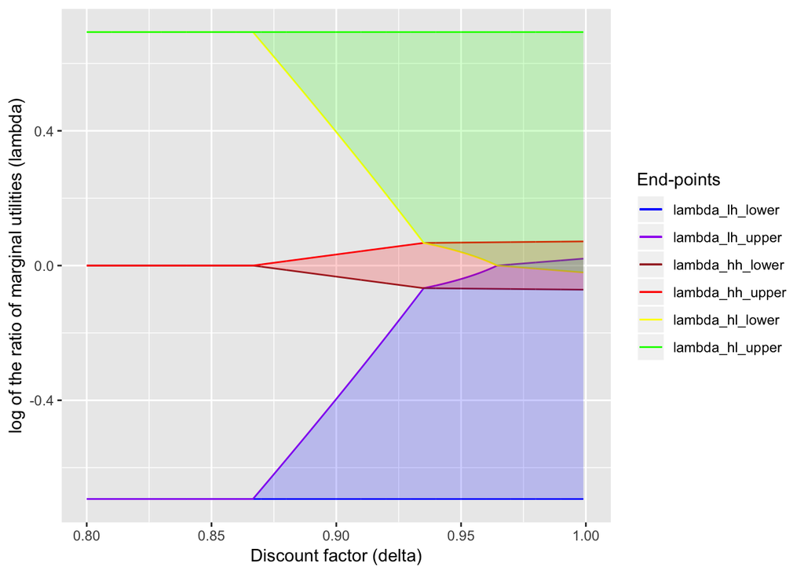

```r
delta_vals <- seq(0.80, 0.999, by = 0.0001)

lambda_lh_upper_vals <- numeric(length(delta_vals))
lambda_hh_lower_vals <- numeric(length(delta_vals))
lambda_hh_upper_vals <- numeric(length(delta_vals))
lambda_hl_lower_vals <- numeric(length(delta_vals))
x_start <- rep((y_l + y_h) / 2, 8)
for (delta in 1:length(delta_vals)){
  if (delta_vals[delta] <= delta_1){
    lambda_lh_upper_vals[delta] <- y_l / y_h
    lambda_hh_lower_vals[delta] <- 1
    lambda_hh_upper_vals[delta] <- 1
    lambda_hl_lower_vals[delta] <- y_h / y_l
  } else if (delta_vals[delta] > delta_1 & delta_vals[delta] <= delta_2){
    lambda_lh_upper_vals[delta] <- lambda_lh_upper_vals_no_overlap[delta]
    lambda_hh_lower_vals[delta] <- lambda_hh_lower_vals_no_overlap[delta]
    lambda_hh_upper_vals[delta] <- lambda_hh_upper_vals_no_overlap[delta]
    lambda_hl_lower_vals[delta] <- lambda_hl_lower_vals_no_overlap[delta]
  } else if (delta_vals[delta] > delta_2 & delta_vals[delta] <= delta_3){
    lambda_lh_upper_vals[delta] <- lambda_lh_upper_vals_overlap[delta]
    lambda_hh_lower_vals[delta] <- lambda_hh_lower_vals_overlap[delta]
    lambda_hh_upper_vals[delta] <- lambda_hh_upper_vals_overlap[delta]
    lambda_hl_lower_vals[delta] <- lambda_hl_lower_vals_overlap[delta]
  } else {
    lambda_lh_upper_vals[delta] <- lambda_lh_upper_vals_first_best[delta]
    lambda_hh_lower_vals[delta] <- lambda_hh_lower_vals_first_best[delta]
    lambda_hh_upper_vals[delta] <- lambda_hh_upper_vals_first_best[delta]
    lambda_hl_lower_vals[delta] <- lambda_hl_lower_vals_first_best[delta]
  }
}

lambda_lh_lower_vals <- rep(y_l / y_h, length(delta_vals))
lambda_hl_upper_vals <- rep(y_h / y_l, length(delta_vals))

ggplot() +
  geom_line(aes(delta_vals, log(lambda_lh_lower_vals), color="a")) +
  geom_line(aes(delta_vals, log(lambda_lh_upper_vals), color="b")) +
  geom_line(aes(delta_vals, log(lambda_hh_lower_vals), color="c")) +
  geom_line(aes(delta_vals, log(lambda_hh_upper_vals), color="d")) +
  geom_line(aes(delta_vals, log(lambda_hl_lower_vals), color="e")) +
  geom_line(aes(delta_vals, log(lambda_hl_upper_vals), color="f")) +
  coord_cartesian(xlim = c(0.8, 1.0)) +
  geom_ribbon(aes(x = delta_vals,
                  ymin = log(lambda_lh_lower_vals),
                  ymax = log(lambda_lh_upper_vals)),
                  fill = "blue", alpha = "0.2") +
  geom_ribbon(aes(x = delta_vals,
                  ymin = log(lambda_hh_lower_vals),
                  ymax = log(lambda_hh_upper_vals)),
                  fill = "red", alpha = "0.2") +
  geom_ribbon(aes(x = delta_vals,
                  ymin = log(lambda_hl_lower_vals),
                  ymax = log(lambda_hl_upper_vals)),
                  fill = "green", alpha = "0.2") +
  scale_color_manual(name = "End-points",
                     values = c("blue", "purple", "brown", "red", "yellow", "green"),
                     labels = c("lambda_lh_lower",
                                "lambda_lh_upper",
                                "lambda_hh_lower",
                                "lambda_hh_upper",
                                "lambda_hl_lower",
                                "lambda_hl_upper")) +
  xlab("Discount factor (delta)") +
  ylab("log of the ratio of marginal utilities (lambda)")
```

I could replicate the figure! Yay!!

The cutoffs of the regions are $\delta_1 = 0.8666$, $\delta_2 = 0.9351$, and $\delta_3 = 0.9645$.